# R4DS_3.6-3.10

## 3.9 Coordinate systems

ggplot defaults to an x,y cartesian coordinate system, but you can also use `coord_polar()` and `coord_quickmap()` for latitude/longitude points.

If you have a plot, you can easy flip the coordinates of that plot with `coord_flip()`

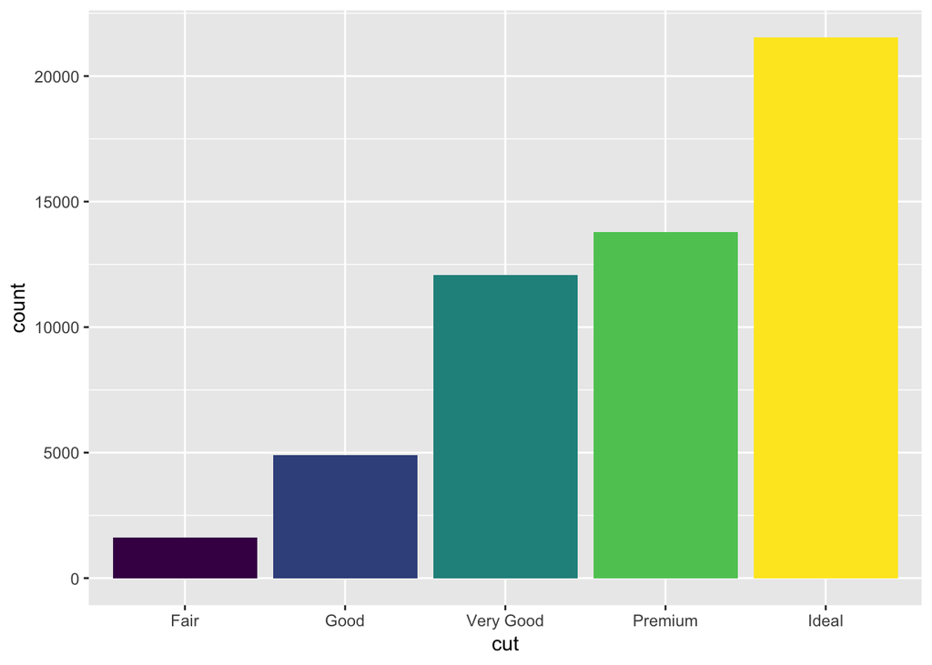

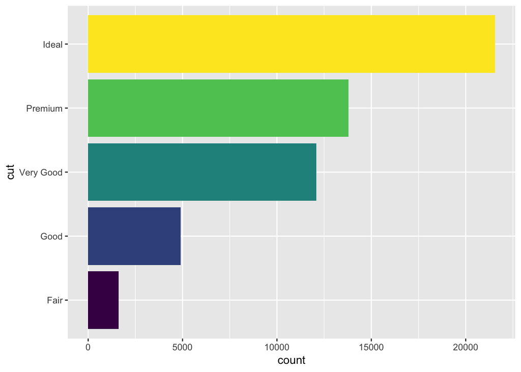

```r
bar <- ggplot(data = diamonds) +
  geom_bar(mapping = aes(x = cut, fill = cut), show.legend = FALSE)


bar
bar + coord_flip()
```

## 3.10 The layered grammar of graphics

Using all the functions you have learned in this chapter, we can use this template to layer each piece together:

```
ggplot(data = <DATA>) +
  <GEOM_FUNCTION>(
     mapping = aes(<MAPPINGS>),
     stat = <STAT>,
     position = <POSITION>
  ) +
  <COORDINATE_FUNCTION> +
  <FACET_FUNCTION>
```

Not every plot needs all of these to be a good plot.